# 3) Working with sequences

Eric Archer

2026-11-04

There are several functions for working with sequence data in strataG. They will either take a haploid *gtypes* object that contains sequences or some format that can be converted to a *DNAbin* (in the *ape* package), or *multidna* (in the *apex* package) object.

Leading and trailing N’s can be removed from all sequences like this:

```r
library(ape)
data(dolph.seqs)

i <- sample(1:10, 1)
j <- sample(1:10, 1)
x <- c(rep("n", i), dolph.seqs[[1]], rep("n", j))
x
```

```
  [1] "n" "n" "n" "n" "g" "a" "a" "a" "a" "a" "-" "g" "c" "t" "t" "a" "t" "t"
 [19] "g" "t" "a" "c" "a" "g" "t" "t" "a" "c" "c" "a" "c" "a" "a" "c" "a" "t"
 [37] "c" "a" "c" "a" "g" "t" "a" "c" "t" "a" "c" "g" "t" "c" "a" "g" "t" "a"
 [55] "t" "t" "a" "a" "a" "a" "g" "t" "a" "a" "t" "t" "t" "g" "t" "t" "t" "t"
 [73] "a" "a" "a" "a" "a" "c" "a" "t" "t" "t" "t" "a" "c" "t" "g" "t" "a" "c"
 [91] "a" "c" "a" "t" "t" "a" "c" "a" "t" "a" "t" "a" "c" "a" "t" "a" "c" "a"
[109] "c" "a" "t" "g" "t" "g" "c" "a" "t" "g" "c" "t" "a" "a" "t" "a" "t" "t"
[127] "t" "a" "g" "t" "c" "-" "t" "c" "t" "c" "c" "t" "t" "g" "t" "a" "a" "a"
[145] "t" "a" "t" "t" "c" "a" "t" "a" "c" "a" "t" "a" "c" "a" "t" "g" "c" "t"
[163] "a" "t" "g" "t" "a" "t" "t" "a" "t" "t" "g" "t" "g" "c" "a" "t" "t" "c"
[181] "a" "t" "t" "t" "a" "t" "t" "t" "t" "c" "c" "a" "t" "a" "c" "g" "a" "t"
[199] "a" "a" "g" "t" "t" "a" "a" "a" "g" "c" "c" "c" "g" "t" "a" "t" "t" "a"
[217] "a" "t" "t" "a" "t" "c" "a" "t" "t" "a" "a" "t" "t" "t" "t" "a" "c" "a"
[235] "t" "a" "t" "t" "a" "c" "a" "t" "a" "a" "t" "a" "t" "g" "c" "a" "t" "g"
[253] "c" "t" "c" "t" "t" "a" "c" "a" "t" "a" "t" "t" "a" "t" "a" "t" "c" "t"
[271] "c" "c" "c" "c" "t" "a" "t" "c" "a" "a" "t" "t" "t" "c" "a" "c" "c" "t"
[289] "c" "c" "a" "t" "t" "a" "t" "a" "c" "c" "c" "t" "a" "t" "g" "g" "t" "c"
[307] "a" "c" "t" "c" "c" "a" "t" "t" "a" "g" "a" "t" "c" "a" "c" "g" "a" "g"
[325] "c" "t" "t" "a" "a" "t" "c" "a" "c" "c" "a" "t" "g" "c" "c" "g" "c" "g"
[343] "t" "g" "a" "a" "a" "c" "c" "a" "g" "c" "a" "a" "c" "c" "c" "g" "c" "t"
[361] "c" "g" "g" "c" "a" "g" "g" "g" "a" "t" "c" "c" "c" "t" "c" "t" "t" "c"
[379] "t" "c" "g" "c" "a" "c" "c" "g" "g" "g" "c" "c" "c" "a" "t" "a" "t" "c"
[397] "t" "c" "g" "t" "g" "g" "g" "g" "g" "t" "n" "n" "n" "n" "n" "n" "n" "n"
```

```r
x.trimmed <- trimNs(as.DNAbin(x))
as.character(as.list(x.trimmed))
```

```
[[1]]
  [1] "g" "a" "a" "a" "a" "a" "-" "g" "c" "t" "t" "a" "t" "t" "g" "t" "a" "c"
 [19] "a" "g" "t" "t" "a" "c" "c" "a" "c" "a" "a" "c" "a" "t" "c" "a" "c" "a"
 [37] "g" "t" "a" "c" "t" "a" "c" "g" "t" "c" "a" "g" "t" "a" "t" "t" "a" "a"
 [55] "a" "a" "g" "t" "a" "a" "t" "t" "t" "g" "t" "t" "t" "t" "a" "a" "a" "a"
 [73] "a" "c" "a" "t" "t" "t" "t" "a" "c" "t" "g" "t" "a" "c" "a" "c" "a" "t"
 [91] "t" "a" "c" "a" "t" "a" "t" "a" "c" "a" "t" "a" "c" "a" "c" "a" "t" "g"
[109] "t" "g" "c" "a" "t" "g" "c" "t" "a" "a" "t" "a" "t" "t" "t" "a" "g" "t"
[127] "c" "-" "t" "c" "t" "c" "c" "t" "t" "g" "t" "a" "a" "a" "t" "a" "t" "t"
[145] "c" "a" "t" "a" "c" "a" "t" "a" "c" "a" "t" "g" "c" "t" "a" "t" "g" "t"
[163] "a" "t" "t" "a" "t" "t" "g" "t" "g" "c" "a" "t" "t" "c" "a" "t" "t" "t"
[181] "a" "t" "t" "t" "t" "c" "c" "a" "t" "a" "c" "g" "a" "t" "a" "a" "g" "t"
[199] "t" "a" "a" "a" "g" "c" "c" "c" "g" "t" "a" "t" "t" "a" "a" "t" "t" "a"
[217] "t" "c" "a" "t" "t" "a" "a" "t" "t" "t" "t" "a" "c" "a" "t" "a" "t" "t"
[235] "a" "c" "a" "t" "a" "a" "t" "a" "t" "g" "c" "a" "t" "g" "c" "t" "c" "t"
[253] "t" "a" "c" "a" "t" "a" "t" "t" "a" "t" "a" "t" "c" "t" "c" "c" "c" "c"
[271] "t" "a" "t" "c" "a" "a" "t" "t" "t" "c" "a" "c" "c" "t" "c" "c" "a" "t"
[289] "t" "a" "t" "a" "c" "c" "c" "t" "a" "t" "g" "g" "t" "c" "a" "c" "t" "c"
[307] "c" "a" "t" "t" "a" "g" "a" "t" "c" "a" "c" "g" "a" "g" "c" "t" "t" "a"
[325] "a" "t" "c" "a" "c" "c" "a" "t" "g" "c" "c" "g" "c" "g" "t" "g" "a" "a"
[343] "a" "c" "c" "a" "g" "c" "a" "a" "c" "c" "c" "g" "c" "t" "c" "g" "g" "c"
[361] "a" "g" "g" "g" "a" "t" "c" "c" "c" "t" "c" "t" "t" "c" "t" "c" "g" "c"
[379] "a" "c" "c" "g" "g" "g" "c" "c" "c" "a" "t" "a" "t" "c" "t" "c" "g" "t"
[397] "g" "g" "g" "g" "g" "t"
```

Base frequencies for a sequence are calculated with the *baseFreqs()* function:

```r
bf <- baseFreqs(dolph.seqs)
bf$site.freqs[, 1:8]
```

```
    1   2   3   4   5   6   7   8
a   0 126 126 126 126 126   5   0
c   0   0   0   0   0   0   0   0
g 126   0   0   0   0   0   0 126
t   0   0   0   0   0   0   0   0
u   0   0   0   0   0   0   0   0
r   0   0   0   0   0   0   0   0
y   0   0   0   0   0   0   0   0
m   0   0   0   0   0   0   0   0
k   0   0   0   0   0   0   0   0
w   0   0   0   0   0   0   0   0
s   0   0   0   0   0   0   0   0
b   0   0   0   0   0   0   0   0
d   0   0   0   0   0   0   0   0
h   0   0   0   0   0   0   0   0
v   0   0   0   0   0   0   0   0
n   0   0   0   0   0   0   0   0
x   0   0   0   0   0   0   0   0
-   0   0   0   0   0   0 121   0
.   0   0   0   0   0   0   0   0
```

```r
bf$base.freqs
```

```
    a     c     g     t     u     r     y     m     k     w     s     b     d
15179 11561  6501 17166     0     0     0     0     0     0     0     0     0
    h     v     n     x     -     .
    0     0     0     0   245     0
```

One can also identify which sites are fixed and which are variable:

```r
fs <- fixedSites(dolph.seqs)
fs[1:20]
```

```
  1   2   3   4   5   6   8   9  10  11  12  13  14  15  16  17  18  19  21  22
"g" "a" "a" "a" "a" "a" "g" "c" "t" "t" "a" "t" "t" "g" "t" "a" "c" "a" "t" "t"
```

```r
vs <- variableSites(dolph.seqs)
vs
```

```
$sites
126 DNA sequences in binary format stored in a matrix.

All sequences of same length: 43

Labels:
4495
4496
4498
5814
5815
5816
...

Base composition:
    a     c     g     t
0.206 0.359 0.088 0.347
(Total: 5.4 kb)

$site.freqs
    7  20  32  57  92  97  99 101 104 106 109 128 149 150 151 205 245 248 265
a   5   2   0   1 124   0   0   0 125 124   0   0   0 124   0   0   0   2   2
c   0   0  10   0   0   7 115   6   0   0  12   0 112   0   2 102 114   0  31
g   0 124   0 125   2   0   0   0   1   2   0   0   0   2   0   0   0 124   0
t   0   0 116   0   0 119  11 120   0   0 114   2  14   0 124  24  12   0  93
- 121   0   0   0   0   0   0   0   0   0   0 124   0   0   0   0   0   0   0
  269 272 274 275 278 279 280 282 283 287 293 294 302 303 305 329 357 370 373
a   0 123   1 123   0   0   0   0   0 125   0   0   0  78   0   0   0   0   0
c  99   0 124   0  10  14   2  98  97   0  84  97 124   0   4 112 124  77   4
g   0   3   0   3   0   0   0   0   0   1   0   0   0  48   0   0   0   0   0
t  27   0   1   0 116 112 124  28  29   0  42  29   2   0 122  14   2  49 122
-   0   0   0   0   0   0   0   0   0   0   0   0   0   0   0   0   0   0   0
  390 391 392 393 394
a 108   0   0   0   0
c   0  27 125   1 125
g  18   0   0   0   0
t   0  99   1 125   1
-   0   0   0   0   0
```

Both functions take an optional set of bases to consider when evaluating whether a site is fixed or variable. For *fixedSites()*, the function will only count those sites that are fixed in the listed *bases* argument. For *variableSites()* the site is considered variable if it has those bases and is not fixed for them:

```r
fs <- fixedSites(dolph.seqs, bases = c("c", "t"))
fs[1:20]
```

```
  9  10  11  13  14  16  18  21  22  24  25  27  30  33  35  38  40  41  43  45
"c" "t" "t" "t" "t" "t" "c" "t" "t" "c" "c" "c" "c" "c" "c" "t" "c" "t" "c" "t"
```

```r
vs <- variableSites(dolph.seqs, bases = c("c", "t"))
vs
```

```
$sites
126 DNA sequences in binary format stored in a matrix.

All sequences of same length: 29

Labels:
4495
4496
4498
5814
5815
5816
...

Base composition:
    a     c     g     t
0.001 0.509 0.000 0.490
(Total: 3.6 kb)

$site.freqs
   32  97  99 101 109 149 151 205 245 265 269 274 278 279 280 282 283 293 294
c  10   7 115   6  12 112   2 102 114  31  99 124  10  14   2  98  97  84  97
t 116 119  11 120 114  14 124  24  12  93  27   1 116 112 124  28  29  42  29
  302 305 329 357 370 373 391 392 393 394
c 124   4 112 124  77   4  27 125   1 125
t   2 122  14   2  49 122  99   1 125   1
```

There are also functions to compare bases against IUPAC ambiguity codes. One can calculate the appropriate IUPAC code for a vector of nucleotides:

```r
iupacCodes(c("c", "t", "t", "c", "c"))
```

```
[1] "y"
```

```r
iupacCodes(c("c", "t", "a", "c", "c"))
```

```
[1] "h"
```

```r
iupacCodes(c("g", "t", "a", "c", "c"))
```

```
[1] "n"
```

One can also calculate all IUPAC codes that apply to a vector of nucleotides:

```r
iupacCodes(c("c", "t", "t", "c", "c"), all = TRUE)
```

```
[1] "y" "b" "h" "n" "x" "-" "."
```

```r
iupacCodes(c("c", "t", "a", "c", "c"), all = TRUE)
```

```
[1] "h" "n" "x" "-" "."
```

```r
iupacCodes(c("g", "t", "a", "c", "c"), all = TRUE)
```

```
[1] "n" "x" "-" "."
```

A consensus sequence can also be generated for an alignment:

```r
createConsensus(dolph.seqs)
```

```
  [1] "g" "a" "a" "a" "a" "a" "-" "g" "c" "t" "t" "a" "t" "t" "g" "t" "a" "c"
 [19] "a" "r" "t" "t" "a" "c" "c" "a" "c" "a" "a" "c" "a" "y" "c" "a" "c" "a"
 [37] "g" "t" "a" "c" "t" "a" "c" "g" "t" "c" "a" "g" "t" "a" "t" "t" "a" "a"
 [55] "a" "a" "r" "t" "a" "a" "t" "t" "t" "g" "t" "t" "t" "t" "a" "a" "a" "a"
 [73] "a" "c" "a" "t" "t" "t" "t" "a" "c" "t" "g" "t" "a" "c" "a" "c" "a" "t"
 [91] "t" "r" "c" "a" "t" "a" "y" "a" "y" "a" "y" "a" "c" "r" "c" "r" "t" "g"
[109] "y" "g" "c" "a" "t" "g" "c" "t" "a" "a" "t" "a" "t" "t" "t" "a" "g" "t"
[127] "c" "-" "t" "c" "t" "c" "c" "t" "t" "g" "t" "a" "a" "a" "t" "a" "t" "t"
[145] "c" "a" "t" "a" "y" "r" "y" "a" "c" "a" "t" "g" "c" "t" "a" "t" "g" "t"
[163] "a" "t" "t" "a" "t" "t" "g" "t" "g" "c" "a" "t" "t" "c" "a" "t" "t" "t"
[181] "a" "t" "t" "t" "t" "c" "c" "a" "t" "a" "c" "g" "a" "t" "a" "a" "g" "t"
[199] "t" "a" "a" "a" "g" "c" "y" "c" "g" "t" "a" "t" "t" "a" "a" "t" "t" "a"
[217] "t" "c" "a" "t" "t" "a" "a" "t" "t" "t" "t" "a" "c" "a" "t" "a" "t" "t"
[235] "a" "c" "a" "t" "a" "a" "t" "a" "t" "g" "y" "a" "t" "r" "c" "t" "c" "t"
[253] "t" "a" "c" "a" "t" "a" "t" "t" "a" "t" "a" "t" "h" "t" "c" "c" "y" "c"
[271] "t" "r" "t" "h" "r" "a" "t" "y" "y" "y" "a" "y" "y" "t" "c" "c" "r" "t"
[289] "t" "a" "t" "a" "y" "y" "c" "t" "a" "t" "g" "g" "t" "y" "r" "c" "y" "c"
[307] "c" "a" "t" "t" "a" "g" "a" "t" "c" "a" "c" "g" "a" "g" "c" "t" "t" "a"
[325] "a" "t" "c" "a" "y" "c" "a" "t" "g" "c" "c" "g" "c" "g" "t" "g" "a" "a"
[343] "a" "c" "c" "a" "g" "c" "a" "a" "c" "c" "c" "g" "c" "t" "y" "g" "g" "c"
[361] "a" "g" "g" "g" "a" "t" "c" "c" "c" "y" "c" "t" "y" "c" "t" "c" "g" "c"
[379] "a" "c" "c" "g" "g" "g" "c" "c" "c" "a" "t" "r" "y" "y" "y" "y" "g" "t"
[397] "g" "g" "g" "g" "g" "t"
```

Nucleotide diversity for each site is calculaed with:

```r
nd <- nucleotideDiversity(dolph.seqs)
head(nd)
```

```
1 2 3 4 5 6
0 0 0 0 0 0
```

*summarizeSeqs()*: Produces a summary of each sequence, including the start and end points, length, number of N’s, and number of indels:

```r
library(ape)
data(dolph.seqs)
seqs.db <- as.DNAbin(dolph.seqs)

seq.smry <- summarizeSeqs(seqs.db)
head(seq.smry)
```

```
     start end length num.ns num.indels
4495     1 402    402      0          2
4496     1 402    402      0          2
4498     1 402    402      0          1
5814     1 402    402      0          2
5815     1 402    402      0          2
5816     1 402    402      0          2
```

Unusual sequences can be identified with a variety of functions:

*sequenceLikelihoods()*: Calculates the likelihood of sequences in an alignment based on gamma distribution of pairwise distances.

```r
data(dolph.haps)
hap.db <- as.DNAbin(dolph.haps)

hap.lik <- sequenceLikelihoods(hap.db)
```

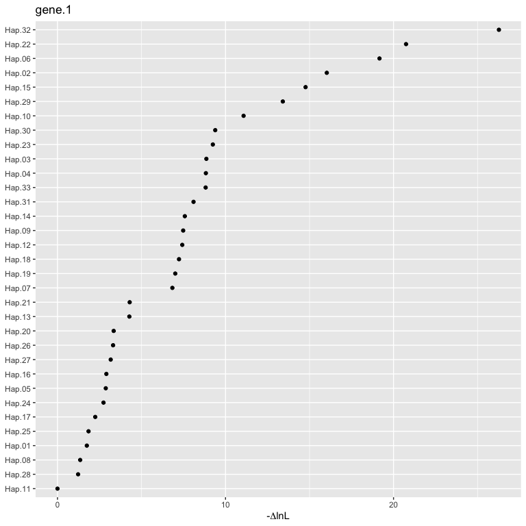

```r
hap.lik
```

```
       id mean.dist neg.log.lik delta.log.lik
1  Hap.32      13.7         110          26.3
2  Hap.22      12.7         104          20.7
3  Hap.06      13.1         102          19.2
4  Hap.02       6.3          99          16.0
5  Hap.15       7.4          98          14.8
6  Hap.29      11.8          97          13.4
7  Hap.10       7.8          94          11.1
8  Hap.30       8.9          93           9.4
9  Hap.23       9.7          93           9.2
10 Hap.03       7.1          92           8.9
11 Hap.04       8.1          92           8.8
12 Hap.33       7.9          92           8.8
13 Hap.31       7.2          91           8.1
14 Hap.14       8.2          91           7.6
```

[output cut: 19 more lines]

*lowFreqSubs()*: Scan a sequence alignment for low frequency substitutions. These may indicate errors in the sequencing process:

```r
low.freq <- lowFreqSubs(seqs.db, min.freq = 2)

low.freq
```

```
     id site base freq       motif
1 23792  274    t    1 cctattgatcc
2 23794  287    g    1 cctccgttata
3 26304  274    a    1 cctataaatcc
4 26304  394    t    1 taccttgtggg
5 74962   57    a    1 taaaaataatt
6 74962  104    g    1 catacgcatgt
7 74962  392    t    1 catgctccgtg
8 74962  393    c    1 atgctccgtgg
```

*mostDistantSequences()*: Uses multi-dimensional scaling to identify sequences at the margins of the multi-dimensional spatial cloud of sequences:

```r
mostDistantSequences(seqs.db, num.seqs = 5)
```

```
[1] "74962" "6290"  "4498"  "18652" "5815"
```

*mostRepresentativeSequences()*: This is kind of theThe opposite of the above, which finds the sequences closest to the center of the multi-dimensional cloud.

```r
mostRepresentativeSequences(seqs.db, num.seqs = 5)
```

```
[1] "6153"  "26305" "26316" "78048" "78063"
```